# Project: Investigate a Dataset - The Movie Database (TMDb)

- Introduction
- Data Wrangling
- Exploratory Data Analysis
- Conclusions

## Introduction

### Dataset Description

This data set contains information about 10,000 movies collected from The Movie Database (TMDb), including user ratings and revenue.

#### Column Names

- id - A unique identifier for each movie.
- imdb_id - A unique identifier for each movie on IMDB.
- popularity - A numeric quantity specifying the movie popularity.
- budget - The budget in which the movie was made.
- revenue - The worldwide revenue generated by the movie.
- original_title - The title of the movie before translation or adaptation.
- cast - The name of lead and supporting actors.
- homepage - A link to the homepage of the movie.
- director - the director of the movie
- tagline - Movie's tagline.
- keywords - The keywords or tags related to the movie.
- overview - A brief description of the movie.
- runtime - The running time of the movie in minutes.
- genre - The genre of the movie, Action, Comedy ,Thriller etc.
- production_companies - The production house of the movie.
- release_date - The date on which it was released.
- vote_count - Number of people vote for a specific movie.
- vote_average - Average ratings the movie recieved.
- release_year - The year when the movie is released
- budget_adj - The budget associated movie in terms of 2010 dollars.
- revenue_adj - The revenue associated movie in terms of 2010 dollars.

### Questions for Analysis

In the following analysis, we are going to find out answers for the following 4 questions. We will address these questions in the **data analysis** and **conclusion** sections.

1. What are the top 4 movies with the highest budgets?
2. What are the top 4 movies with the highest revenue?
3. What are the top 4 most popular movies?
4. Does the budget or revenue of a movie impact its popularity?

### Import Package

First, we are going to import the following packages, which are essential for our data analysis.

- Numpy - NumPy is a fundamental Python library for numerical computing, providing support for arrays, matrices, and various mathematical functions.
- Pandas - Pandas is a Python library used for data manipulation and analysis, offering data structures like DataFrames and Series.
- Matplotlib - Matplotlib is a Python library for creating static, interactive, and animated visualizations, offering a variety of plotting functions.

```python
# importing the packages.

import pandas as pd
import numpy as ny
import matplotlib.pyplot as plt
```

## Data Wrangling

The Data Wrangling process involves cleaning and transforming the dataset to ensure it is suitable for analysis. In this section, we will detail the steps taken to prepare the TMDb dataset for analysis, including identifying and handling missing data, correcting data types, removing duplicates etc.

### Loading Dataset

First, we load the TMDb dataset into a pandas DataFrame to explore its structure and content.

```python
# Load the dataset.
df = pd.read_csv('Database_TMDb_movie_data/tmdb-movies.csv')

# Display the first few rows of the dataset.
df.head()
```

|  | id | imdb_id | popularity | budget | revenue | original_title | cast | homepage | director | tagline | ... | overview | runtime | genres | production_companies | release_date | vote_count | vote_average | release_year | budget_adj | revenue_adj |
| --- | --- | --- | --- | --- | --- | --- | --- | --- | --- | --- | --- | --- | --- | --- | --- | --- | --- | --- | --- | --- | --- |
| 0 | 135397 | tt0369610 | 32.985763 | 150000000 | 1513528810 | Jurassic World | Chris Pratt\|Bryce Dallas Howard\|Irrfan Khan\|Vi... | http://www.jurassicworld.com/ | Colin Trevorrow | The park is open. | ... | Twenty-two years after the events of Jurassic ... | 124 | Action\|Adventure\|Science Fiction\|Thriller | Universal Studios\|Amblin Entertainment\|Legenda... | 6/9/15 | 5562 | 6.5 | 2015 | 1.379999e+08 | 1.392446e+09 |
| 1 | 76341 | tt1392190 | 28.419936 | 150000000 | 378436354 | Mad Max: Fury Road | Tom Hardy\|Charlize Theron\|Hugh Keays-Byrne\|Nic... | http://www.madmaxmovie.com/ | George Miller | What a Lovely Day. | ... | An apocalyptic story set in the furthest reach... | 120 | Action\|Adventure\|Science Fiction\|Thriller | Village Roadshow Pictures\|Kennedy Miller Produ... | 5/13/15 | 6185 | 7.1 | 2015 | 1.379999e+08 | 3.481613e+08 |
| 2 | 262500 | tt2908446 | 13.112507 | 110000000 | 295238201 | Insurgent | Shailene Woodley\|Theo James\|Kate Winslet\|Ansel... | http://www.thedivergentseries.movie/#insurgent | Robert Schwentke | One Choice Can Destroy You | ... | Beatrice Prior must confront her inner demons ... | 119 | Adventure\|Science Fiction\|Thriller | Summit Entertainment\|Mandeville Films\|Red Wago... | 3/18/15 | 2480 | 6.3 | 2015 | 1.012000e+08 | 2.716190e+08 |
| 3 | 140607 | tt2488496 | 11.173104 | 200000000 | 2068178225 | Star Wars: The Force Awakens | Harrison Ford\|Mark Hamill\|Carrie Fisher\|Adam D... | http://www.starwars.com/films/star-wars-episod... | J.J. Abrams | Every generation has a story. | ... | Thirty years after defeating the Galactic Empi... | 136 | Action\|Adventure\|Science Fiction\|Fantasy | Lucasfilm\|Truenorth Productions\|Bad Robot | 12/15/15 | 5292 | 7.5 | 2015 | 1.839999e+08 | 1.902723e+09 |
| 4 | 168259 | tt2820852 | 9.335014 | 190000000 | 1506249360 | Furious 7 | Vin Diesel\|Paul Walker\|Jason Statham\|Michelle ... | http://www.furious7.com/ | James Wan | Vengeance Hits Home | ... | Deckard Shaw seeks revenge against Dominic Tor... | 137 | Action\|Crime\|Thriller | Universal Pictures\|Original Film\|Media Rights ... | 4/1/15 | 2947 | 7.3 | 2015 | 1.747999e+08 | 1.385749e+09 |

5 rows × 21 columns

### Inspecting the Data

To understand the dataset, we need to inspect its structure, including the number of rows and columns, column names, data types, and summary statistics.

```python
# Display the shape of the dataset.
df.shape
```

```
(10866, 21)
```

```python
# Display data types of each column.
df.dtypes
```

```
id                        int64
imdb_id                  object
popularity              float64
budget                    int64
revenue                   int64
original_title           object
cast                     object
homepage                 object
director                 object
tagline                  object
keywords                 object
overview                 object
runtime                   int64
genres                   object
production_companies     object
release_date             object
vote_count                int64
vote_average            float64
release_year              int64
budget_adj              float64
revenue_adj             float64
dtype: object
```

```python
# Display non-num count and data type for each variable.
df.info()
```

```
<class 'pandas.core.frame.DataFrame'>
RangeIndex: 10866 entries, 0 to 10865
Data columns (total 21 columns):
 #   Column                Non-Null Count  Dtype
---  ------                --------------  -----
 0   id                    10866 non-null  int64
 1   imdb_id               10856 non-null  object
 2   popularity            10866 non-null  float64
 3   budget                10866 non-null  int64
 4   revenue               10866 non-null  int64
 5   original_title        10866 non-null  object
 6   cast                  10790 non-null  object
 7   homepage              2936 non-null   object
 8   director              10822 non-null  object
 9   tagline               8042 non-null   object
 10  keywords              9373 non-null   object
 11  overview              10862 non-null  object
 12  runtime               10866 non-null  int64
 13  genres                10843 non-null  object
 14  production_companies  9836 non-null   object
 15  release_date          10866 non-null  object
 16  vote_count            10866 non-null  int64
 17  vote_average          10866 non-null  float64
 18  release_year          10866 non-null  int64
 19  budget_adj            10866 non-null  float64
 20  revenue_adj           10866 non-null  float64
dtypes: float64(4), int64(6), object(11)
memory usage: 1.7+ MB
```

```python
# Summary statistics.
df.describe()
```

|  | id | popularity | budget | revenue | runtime | vote_count | vote_average | release_year | budget_adj | revenue_adj |
| --- | --- | --- | --- | --- | --- | --- | --- | --- | --- | --- |
| count | 10866.000000 | 10866.000000 | 1.086600e+04 | 1.086600e+04 | 10866.000000 | 10866.000000 | 10866.000000 | 10866.000000 | 1.086600e+04 | 1.086600e+04 |
| mean | 66064.177434 | 0.646441 | 1.462570e+07 | 3.982332e+07 | 102.070863 | 217.389748 | 5.974922 | 2001.322658 | 1.755104e+07 | 5.136436e+07 |
| std | 92130.136561 | 1.000185 | 3.091321e+07 | 1.170035e+08 | 31.381405 | 575.619058 | 0.935142 | 12.812941 | 3.430616e+07 | 1.446325e+08 |
| min | 5.000000 | 0.000065 | 0.000000e+00 | 0.000000e+00 | 0.000000 | 10.000000 | 1.500000 | 1960.000000 | 0.000000e+00 | 0.000000e+00 |
| 25% | 10596.250000 | 0.207583 | 0.000000e+00 | 0.000000e+00 | 90.000000 | 17.000000 | 5.400000 | 1995.000000 | 0.000000e+00 | 0.000000e+00 |
| 50% | 20669.000000 | 0.383856 | 0.000000e+00 | 0.000000e+00 | 99.000000 | 38.000000 | 6.000000 | 2006.000000 | 0.000000e+00 | 0.000000e+00 |
| 75% | 75610.000000 | 0.713817 | 1.500000e+07 | 2.400000e+07 | 111.000000 | 145.750000 | 6.600000 | 2011.000000 | 2.085325e+07 | 3.369710e+07 |
| max | 417859.000000 | 32.985763 | 4.250000e+08 | 2.781506e+09 | 900.000000 | 9767.000000 | 9.200000 | 2015.000000 | 4.250000e+08 | 2.827124e+09 |

### Data Cleaning

Data cleaning is a crucial step in the data analysis process. It involves identifying and correcting (or removing) errors and inconsistencies in the dataset to improve its quality. For the TMDb dataset, the data cleaning process includes handling missing values, removing duplicates, correcting data types, removing rows with error values. Below are the detailed steps taken to clean the TMDb dataset.

#### Drop Unnecessary Columns

Since columns **homepage** and **tagline** have too many null values, we will drop these columns from our dataset. Specifically, homepage has 7,930 null values, and tagline has 2,824 null values, which significantly impacts the overall integrity of the data. Removing these columns will reduce the total number of columns from 21 to 19, helping us focus on the most relevant and complete data for our analysis.

```python
# Drop the specified columns.
df.drop(['homepage', 'tagline'], axis = 1, inplace = True)
```

```python
# Verify that the columns 'homepage' and 'tagline' have been successfully dropped from the data.
df.info()
```

```
<class 'pandas.core.frame.DataFrame'>
RangeIndex: 10866 entries, 0 to 10865
Data columns (total 19 columns):
 #   Column                Non-Null Count  Dtype
---  ------                --------------  -----
 0   id                    10866 non-null  int64
 1   imdb_id               10856 non-null  object
 2   popularity            10866 non-null  float64
 3   budget                10866 non-null  int64
 4   revenue               10866 non-null  int64
 5   original_title        10866 non-null  object
 6   cast                  10790 non-null  object
 7   director              10822 non-null  object
 8   keywords              9373 non-null   object
 9   overview              10862 non-null  object
 10  runtime               10866 non-null  int64
 11  genres                10843 non-null  object
 12  production_companies  9836 non-null   object
 13  release_date          10866 non-null  object
 14  vote_count            10866 non-null  int64
 15  vote_average          10866 non-null  float64
 16  release_year          10866 non-null  int64
 17  budget_adj            10866 non-null  float64
 18  revenue_adj           10866 non-null  float64
dtypes: float64(4), int64(6), object(9)
memory usage: 1.6+ MB
```

#### Drop Rows with Missing Values

From the table above, we see that most missing values are strings. Thus, remove any rows containing missing values to prevent incorrect analyses and insights, potentially skewing results. Assign the refined data to a new DataFrame variable

```python
# Remove rows with missing values.
df = df.dropna()
```

```python
# Verify that all rows with missing values have been successfully dropped from the data.
df.isnull().sum()
```

```
id                      0
imdb_id                 0
popularity              0
budget                  0
revenue                 0
original_title          0
cast                    0
director                0
keywords                0
overview                0
runtime                 0
genres                  0
production_companies    0
release_date            0
vote_count              0
vote_average            0
release_year            0
budget_adj              0
revenue_adj             0
dtype: int64
```

All columns now have no null values.

#### Drop Duplicate Rows

To find the number of duplicate rows in the TMDb dataset and ensure the dataset is clean, use **sum(df_clean.duplicated())** to identify duplicates

```python
# Find total number of duplicate rows in the data.
sum(df.duplicated())
```

```
1
```

There is one duplicated row. Let's drop it

```python
# Drop the duplicate row.
df.drop_duplicates(inplace = True)
```

Verify that the duplicate row has been successfully dropped.

```python
# Verify that the duplicate row has been successfully dropped.
sum(df.duplicated())
```

```
0
```

Now, there is no more duplicate row in the data

#### Drop Rows with Incorrect Values

There are a couple of rows where the column 'runtime' is equal to 0. Additionally, in the same rows, the columns 'budget' and/or 'revenue' are also equal to 0. These are very likely to be typing mistakes, and those rows need to be removed.

```python
# Find rows containing a runtime of zero.

runtime_zero = df['runtime'] == 0
df[runtime_zero]
```

|  | id | imdb_id | popularity | budget | revenue | original_title | cast | director | keywords | overview | runtime | genres | production_companies | release_date | vote_count | vote_average | release_year | budget_adj | revenue_adj |
| --- | --- | --- | --- | --- | --- | --- | --- | --- | --- | --- | --- | --- | --- | --- | --- | --- | --- | --- | --- |
| 92 | 370687 | tt3608646 | 1.876037 | 0 | 0 | Mythica: The Necromancer | Melanie Stone\|Adam Johnson\|Kevin Sorbo\|Nicola ... | A. Todd Smith | sword\|magic\|sorcery\|necromancer | Mallister takes Thane prisoner and forces Mare... | 0 | Fantasy\|Action\|Adventure | Arrowstorm Entertainment\|Camera 40 Productions... | 12/19/15 | 11 | 5.4 | 2015 | 0.000000e+00 | 0.0 |
| 334 | 361931 | tt5065822 | 0.357654 | 0 | 0 | Ronaldo | Cristiano Ronaldo | Anthony Wonke | biography\|soccer player | Filmed over 14 months with unprecedented acces... | 0 | Documentary | On The Corner Films\|We Came, We Saw, We Conque... | 11/9/15 | 80 | 6.5 | 2015 | 0.000000e+00 | 0.0 |
| 486 | 333653 | tt4058368 | 0.176744 | 0 | 0 | If There Be Thorns | Heather Graham\|Jason Lewis\|Rachael Carpani\|Mas... | Nancy Savoca | woman director | The third installment in V.C. Andrews’ bests... | 0 | TV Movie\|Drama | A+E Studios\|Jane Startz Productions | 4/5/15 | 11 | 5.4 | 2015 | 0.000000e+00 | 0.0 |
| 1289 | 286372 | tt1791681 | 0.037459 | 3250000 | 0 | Treehouse | J. Michael Trautmann\|Dana Melanie\|Daniel Fredr... | Michael G. Bartlett | kidnapping\|brutality\|violence\|teenager\|discovery | A teenage boy discovers the perpetrators of se... | 0 | Thriller\|Horror\|Mystery | Tiberius Film | 10/20/14 | 16 | 3.4 | 2014 | 2.993546e+06 | 0.0 |
| 1293 | 286256 | tt3134058 | 0.036904 | 0 | 0 | Tim Maia | Robson Nunes\|Babú Santana\|Alinne Moraes\|Cauã... | Mauro Lima | brazilian\|biography\|music\|drama\|documentary | Biopic of Brazilian singer Tim Maia, from his ... | 0 | Documentary\|Drama\|Music | Globo Filmes | 10/30/14 | 14 | 6.0 | 2014 | 0.000000e+00 | 0.0 |
| 5920 | 248842 | tt2364006 | 0.165765 | 0 | 0 | The Food Guide to Love | Richard Coyle\|Leonor Watling\|Ginés García Mi... | Dominic Harari\|Teresa Pelegri | woman director | A dysfunctional love story about an Irish food... | 0 | Romance\|Comedy | Haut et Court\|Parallel Film Productions\|Fox In... | 12/18/13 | 12 | 5.6 | 2013 | 0.000000e+00 | 0.0 |
| 5938 | 191562 | tt2436516 | 0.147188 | 0 | 0 | Go Goa Gone | Saif Ali Khan\|Anand Tiwari\|Vir Das\|Pooja Gupta | Krishna D.K.\|Raj Nidimoru | hindi\|zombies island\|zombies\|zombie survival | A rave party off the coast of Goa, goes horrif... | 0 | Comedy\|Horror | Eros International | 5/10/13 | 16 | 5.3 | 2013 | 0.000000e+00 | 0.0 |

```python
# Let's remove those rows containing a runtime of zero.

df = df[df['runtime'] != 0]
```

```python
# Verify that rows containing a runtime of zero have been removed.
print(df[df['runtime'] == 0])
```

```
Empty DataFrame
Columns: [id, imdb_id, popularity, budget, revenue, original_title, cast, director, keywords, overview, runtime, genres, production_companies, release_date, vote_count, vote_average, release_year, budget_adj, revenue_adj]
Index: []
```

Now, we have clean data and can proceed with analyzing it.

## Exploratory Data Analysis

The purpose of this exploratory data analysis (EDA) is to understand some main characteristics of the TMDb (The Movie Database) dataset.

### Research Question 1 - What Are the Top 4 Movies with the Highest Budgets?

```python
# Set up a function for plotting bar charts below
# Plot a bar chart for the top 4 entries in the DataFrame based on a specified value column.
def plot_top_4_bar_chart(df, title_col, value_col, x_label, y_label, chart_title):
    plt.figure(figsize=(11, 6))
    plt.bar(df[title_col], df[value_col])
    plt.xlabel(x_label)
    plt.ylabel(y_label)
    plt.title(chart_title)
    plt.xticks(rotation=45)
    plt.show()
```

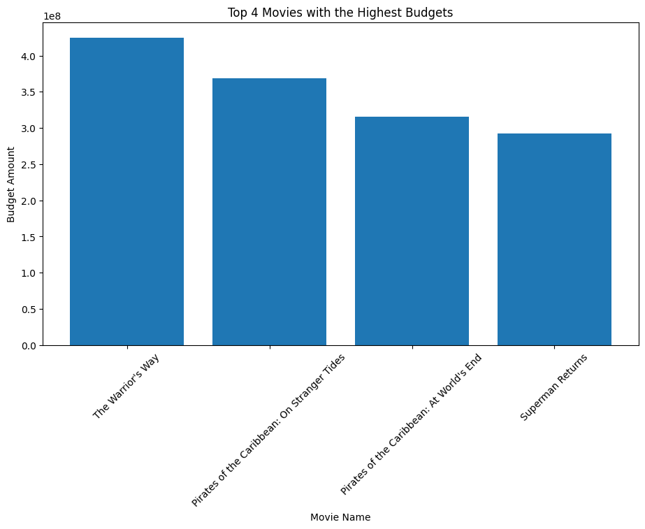

```python
# Sort the dataset by budget_adj in decending order
df_sorted_b = df.sort_values(by='budget_adj', ascending=False)

# Capture the top 4 movies with highest budget amount after adjustment
top_4_budgets = df_sorted_b.head(4)

# Use the bar chart to vitalize the top 4 movies with the highest budgets
plot_top_4_bar_chart(top_4_budgets, 'original_title', 'budget_adj', 'Movie Name', 'Budget Amount', 'Top 4 Movies with the Highest Budgets')
```

The bar chart above shows that the top 4 movies with the highest budgets are

- The Warrior's Way
- Pirates of the Caribbean: On Stranger Tides
- Pirates of the Caribbean: At World's End
- Superman Returns

### Research Question 2 - What Are the Top 4 Movies with the Highest Revenue?

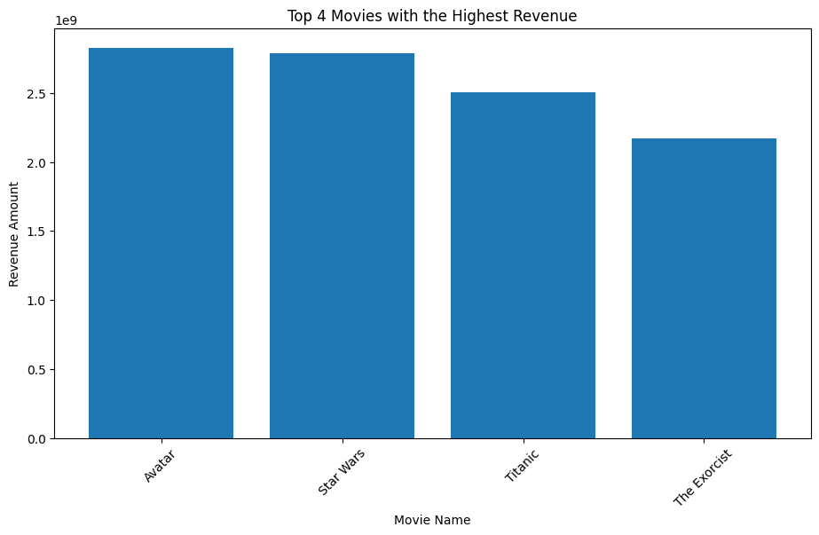

```python
# Sort the dataset by revenue_adj in decending order
df_sorted_r = df.sort_values(by='revenue_adj', ascending=False)

# Capture the top 4 movies with highest revenue amount after adjustment
top_4_revenues = df_sorted_r.head(4)

# Use the bar chart to vitalize the top 4 movies with the highest revenue
plot_top_4_bar_chart(top_4_revenues, 'original_title', 'revenue_adj', 'Movie Name', 'Revenue Amount', 'Top 4 Movies with the Highest Revenue')
```

The bar chart above shows that the top 4 movies with the highest revenue are

- Avatar
- Star Wars
- Titanic
- The Exorcist

### Research Question 3 - What Are the Top 4 Most Popular Movies?

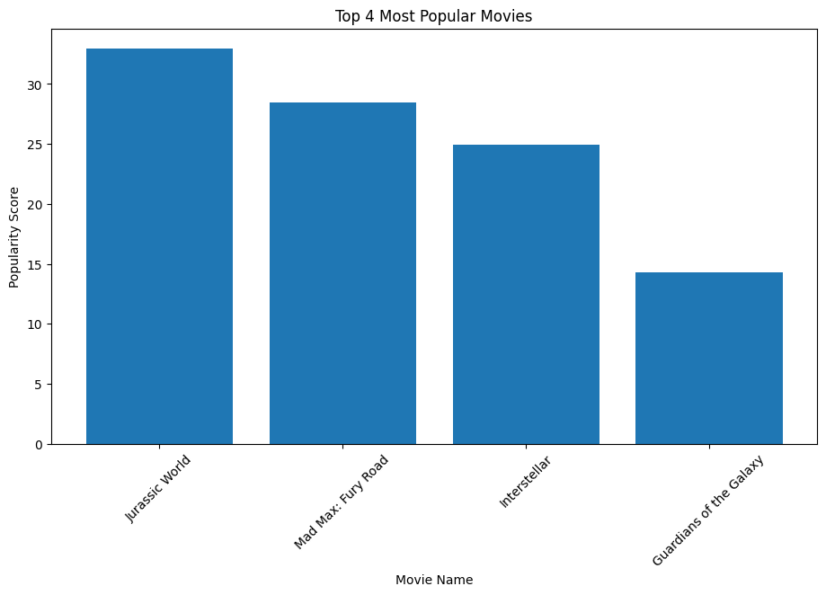

```python
# Sort the dataset by popularity in decending order
df_sorted_p = df.sort_values(by='popularity', ascending=False)

# Capture the top 4 movies with the highest popularity scores
top_4_movies = df_sorted_p.head(4)

# Use the bar chart to vitalize the top 4 movies with the highest popularity scores
plot_top_4_bar_chart(top_4_movies, 'original_title', 'popularity', 'Movie Name', 'Popularity Score', 'Top 4 Most Popular Movies')
```

The bar chart above shows that the top 4 movies with the highest popularity scores are

- Jurassic World
- Mad Max: Fury Road
- Interstellar
- Guardians of the Galaxy

### Research Question 4 - Does the Budget of a Movie Impact Its Popularity?

From the 3 bar charts above, we can see that the top 4 movies with the highest budgets are different from those with the highest popularity scores. Therefore, let's explore whether a higher movie budget can lead to higher popularity.

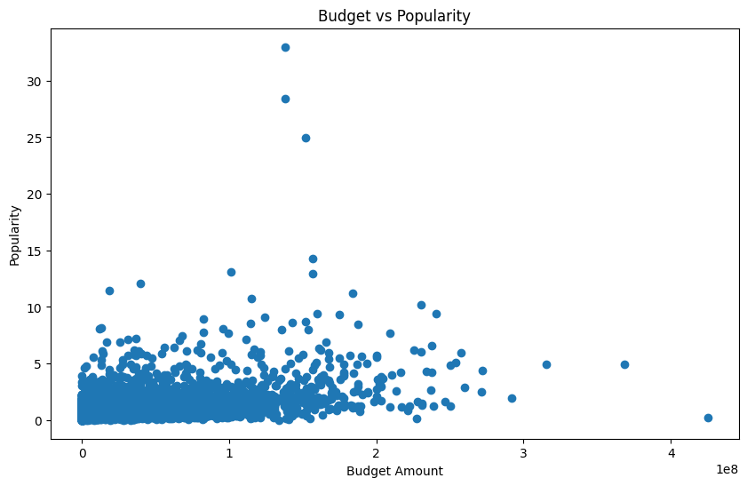

```python
# Setting the size of the plot to 10 inches by 6 inches
plt.figure(figsize=(10, 6))

# Creating a scatter plot with 'budget_adj' on the x-axis and 'popularity' on the y-axis
plt.scatter(df['budget_adj'], df['popularity'])

# Setting the label for the x-axis
plt.xlabel('Budget Amount')

# Setting the label for the y-axis
plt.ylabel('Popularity')

# Setting the title for the plot
plt.title('Budget vs Popularity')

# Displaying the plot
plt.show();
```

### Research Question 5 - Does the Revenue of a Movie Impact Its Popularity?

From the 3 bar charts above, we can see that the top 4 movies with the highest revenue are different from those with the highest popularity scores. Therefore, let's explore whether a higher movie revenue can lead to higher popularity.

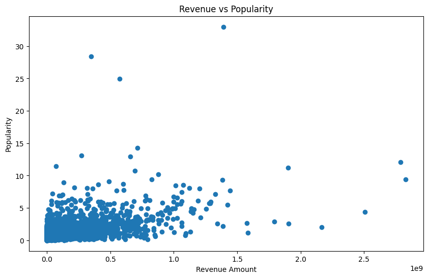

```python
# Set the figure size to 10 inches wide and 6 inches tall
plt.figure(figsize=(10, 6))

# Create a scatter plot with 'revenue_adj' on the x-axis and 'popularity' on the y-axis
plt.scatter(df['revenue_adj'], df['popularity'])

# Set the label for the x-axis
plt.xlabel('Revenue Amount')

# Set the label for the y-axis
plt.ylabel('Popularity')

# Set the title for the plot
plt.title('Revenue vs Popularity')

# Display the plot
plt.show();
```

### Research Question 6 - Does a Movie's Budget Impact Its Revenue?

The movie investors always prioritize returns on their investments. Using TMDb data, let's investigate whether there is a relationship between a movie's budget and its revenue.

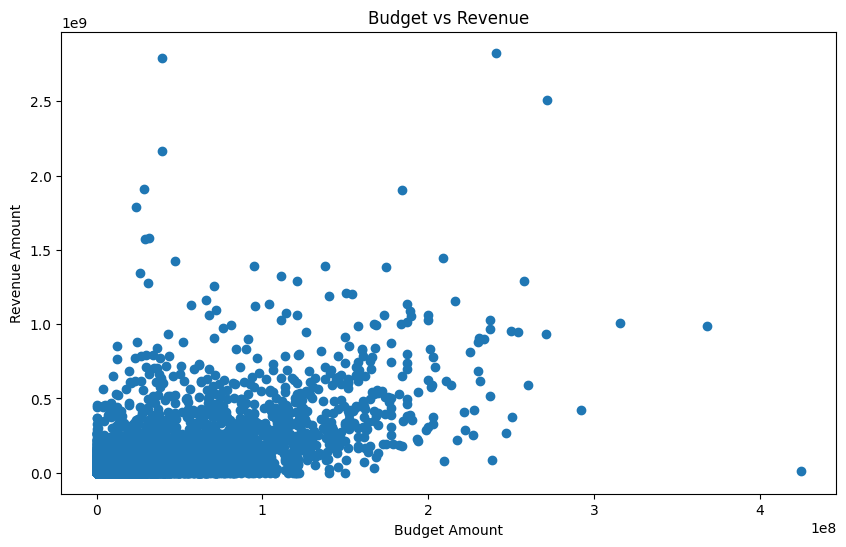

```python
# Setting the size of the plot to 10 inches by 6 inches
plt.figure(figsize=(10, 6))

# Creating a scatter plot with 'budget_adj' on the x-axis and 'revenue_adj' on the y-axis
plt.scatter(df['budget_adj'], df['revenue_adj'])

# Adding a label to the x-axis
plt.xlabel('Budget Amount')

# Adding a label to the y-axis
plt.ylabel('Revenue Amount')

# Adding a title to the plot
plt.title('Budget vs Revenue')

# Displaying the plot
plt.show();
```

## Conclusions

The result shows that the top 4 movies with the **highest budgets** are

- The Warrior's Way
- Pirates of the Caribbean: On Stranger Tides
- Pirates of the Caribbean: At World's End
- Superman Returns

The result shows that the top 4 movies with the **highest revenue** are

- Avatar
- Star Wars
- Titanic
- The Exorcist

The result shows that the top 4 movies with the **highest popularity scores** are

- Jurassic World
- Mad Max: Fury Road
- Interstellar
- Guardians of the Galaxy

From the results above, it's evident that the top 4 movies with the highest budgets, highest revenues, and highest popularity scores are distinct from each other. This observation leads us to think whether movie budget or movie revenue can impact popularity score.

Although no statistical tests have been conducted yet, the scatter plot (Budget vs Popularity) above visually suggests that there is no clear relationship between a movie's budget and its popularity score, indicating that popularity may not be directly influenced by budget.

Although no statistical tests have been conducted yet, the scatter plot (Revenue vs Popularity) above visually suggests that there is no clear relationship between a movie's revenue and its popularity score, indicating that popularity may not be directly influenced by revenue.

On the other hand, although no statistical tests have been conducted yet, the scatter plot (Budget vs Revenue) above visually suggests a positive relationship between a movie's budget and its revenue, indicating that higher budgets may be associated with higher revenues.

### Limitation

- The dataset may have missing or incomplete data in some columns, which can affect the accuracy and comprehensiveness of the analysis.
- This analysis relies on visual inspections of scatter plots to infer relationships. No statistical tests have been conducted to confirm these observations, limiting the robustness of the conclusions.

#### Further Research

- Perform detailed statistical analyses to explore the relationships between variables.
- Conduct temporal analysis to understand trends over time in movie budgets and revenues.

```python
# Running this cell will execute a bash command to convert this notebook to an .html file
!python -m nbconvert --to html Investigate_a_Dataset.ipynb
```

```
[NbConvertApp] Converting notebook Investigate_a_Dataset.ipynb to html
[NbConvertApp] WARNING | Alternative text is missing on 6 image(s).
[NbConvertApp] Writing 624885 bytes to Investigate_a_Dataset.html
```